# Estudios de Informática, Multimedia y Telecomunicaciones

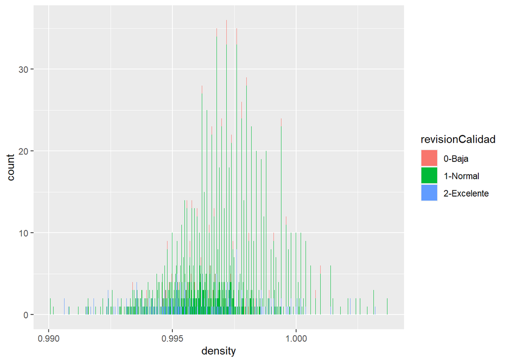

```r
ggplot(data = dataWine[1:filas,],aes(x=density,fill=revisionCalidad))+geom_bar()
```

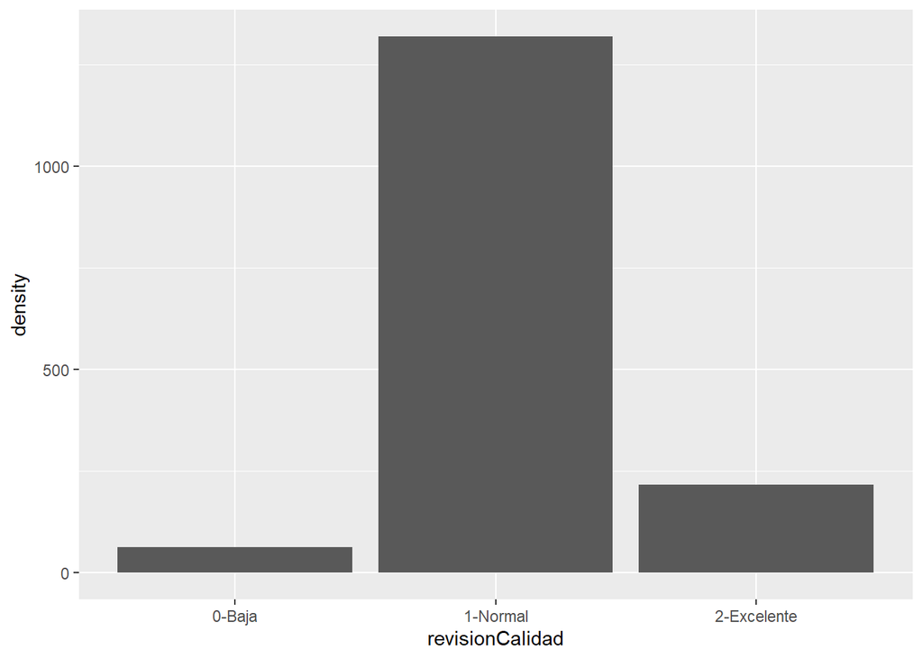

```r
ggplot(data = dataWine[1:filas,],aes(x=revisionCalidad,fill=density))+geom_bar()+ylab("density")
```

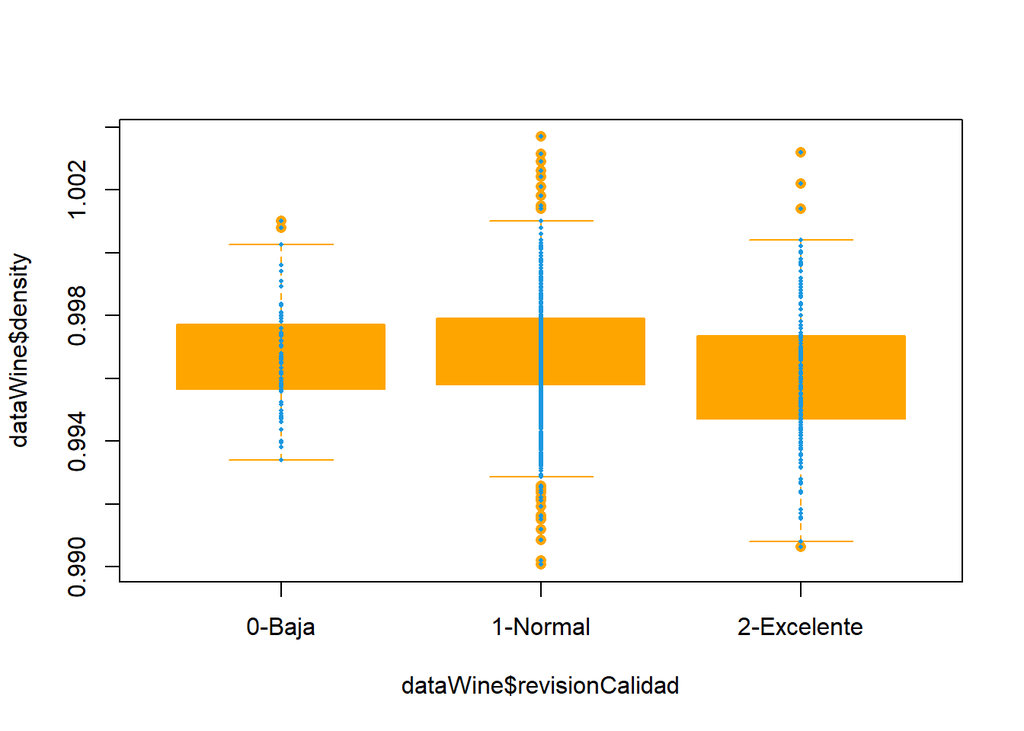

```r
boxplot(dataWine$density ~ dataWine$revisionCalidad,
        col = "orange",
        border = "orange",
        pch = 16)

points(dataWine$revisionCalidad, dataWine$density,
       col = "#1b98e0",
       pch = 16,
       cex = 0.4)
```

```r
#Atributo pH
print("Distribución de pH")
```

```
## [1] "Distribución de pH"
```

```r
summary(dataWine$pH)
```

```
##    Min. 1st Qu.  Median    Mean 3rd Qu.    Max.
##   2.740   3.210   3.310   3.311   3.400   4.010
```

```r
table(sort(dataWine$pH))
```

```
##
## 2.74 2.86 2.87 2.88 2.89  2.9 2.92 2.93 2.94 2.95 2.98 2.99    3 3.01 3.02 3.03
##    1    1    1    2    4    1    4    3    4    1    5    2    6    5    8    6
## 3.04 3.05 3.06 3.07 3.08 3.09  3.1 3.11 3.12 3.13 3.14 3.15 3.16 3.17 3.18 3.19
##   10    8   10   11   11   11   19    9   20   13   21   34   36   27   30   25
##  3.2 3.21 3.22 3.23 3.24 3.25 3.26 3.27 3.28 3.29  3.3 3.31 3.32 3.33 3.34 3.35
##   39   36   39   32   29   26   53   35   42   46   57   39   45   37   43   39
## 3.36 3.37 3.38 3.39  3.4 3.41 3.42 3.43 3.44 3.45 3.46 3.47 3.48 3.49  3.5 3.51
##   56   37   48   48   37   34   33   17   29   20   22   21   19   10   14   15
## 3.52 3.53 3.54 3.55 3.56 3.57 3.58 3.59  3.6 3.61 3.62 3.63 3.66 3.67 3.68 3.69
##   18   17   16    8   11   10   10    8    7    8    4    3    4    3    5    4
##  3.7 3.71 3.72 3.74 3.75 3.78 3.85  3.9 4.01
##    1    4    3    1    1    2    1    2    2
```

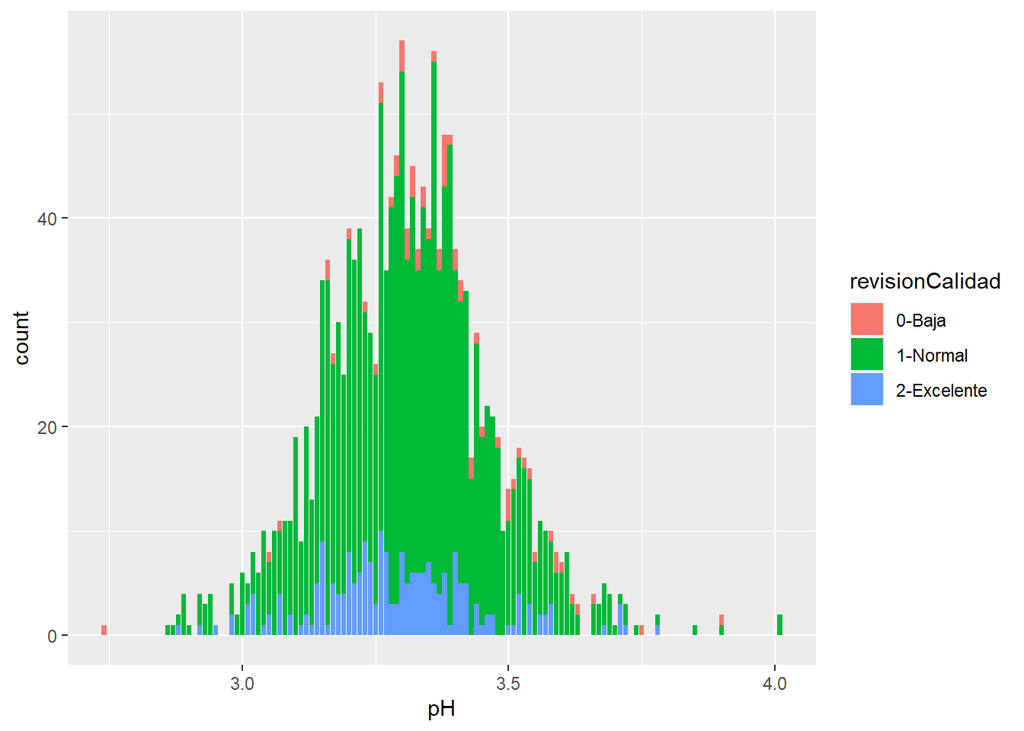

```r
ggplot(data = dataWine[1:filas,],aes(x=pH,fill=revisionCalidad))+geom_bar()
```

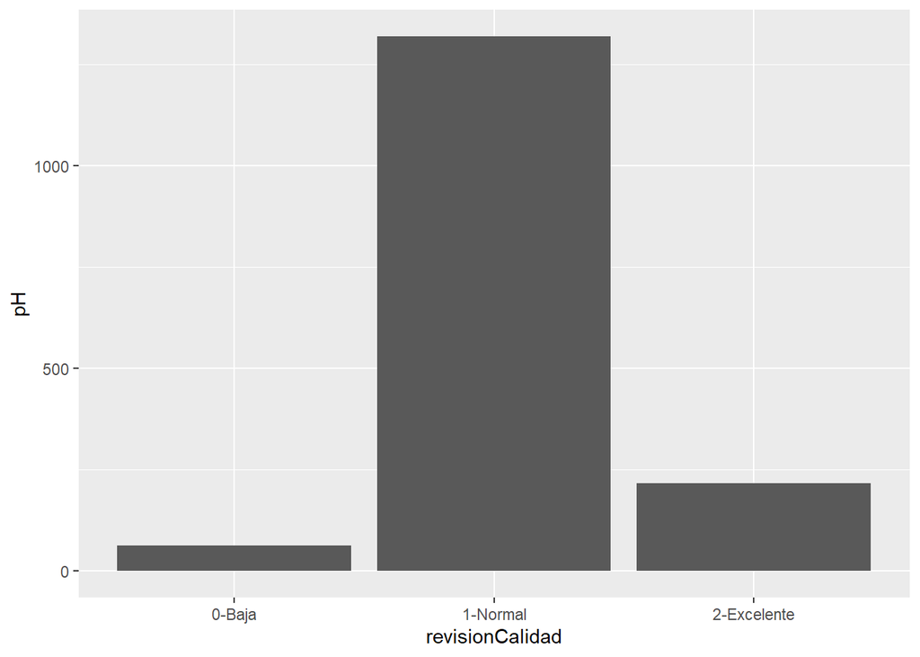

```r
ggplot(data = dataWine[1:filas,],aes(x=revisionCalidad,fill=pH))+geom_bar()+ylab("pH")
```

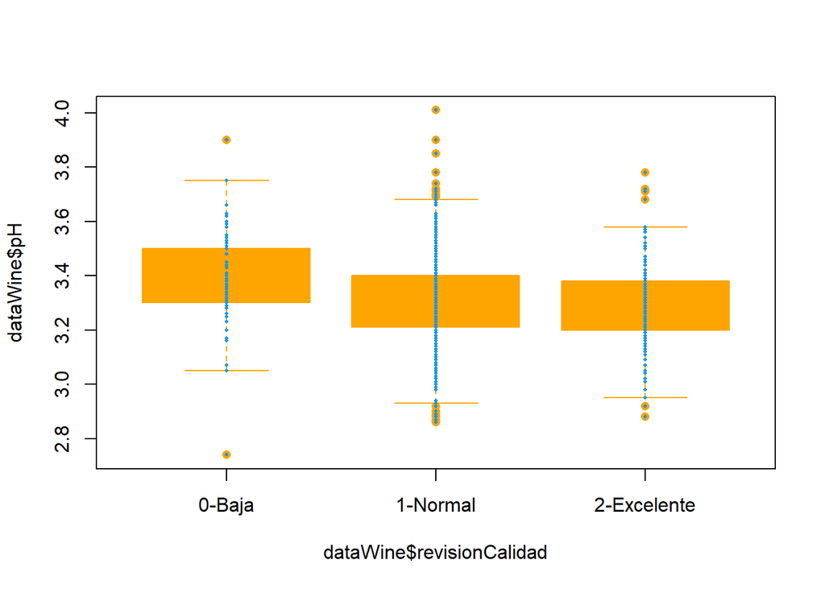

```r
boxplot(dataWine$pH ~ dataWine$revisionCalidad,
        col = "orange",
        border = "orange",
        pch = 16)

points(dataWine$revisionCalidad, dataWine$pH,
       col = "#1b98e0",
       pch = 16,
       cex = 0.4)
```

```r
#Atributo sulphates
print("Distribución de Sulphates")
```

```
## [1] "Distribución de Sulphates"
```

```r
summary(dataWine$sulphates)
```

```
##    Min. 1st Qu.  Median    Mean 3rd Qu.    Max.
##  0.3300  0.5500  0.6200  0.6581  0.7300  2.0000
```

```r
table(sort(dataWine$sulphates))
```

```
##
## 0.33 0.37 0.39  0.4 0.42 0.43 0.44 0.45 0.46 0.47 0.48 0.49  0.5 0.51 0.52 0.53
##    1    2    6    4    5    8   16   12   18   19   29   31   27   26   47   51
## 0.54 0.55 0.56 0.57 0.58 0.59  0.6 0.61 0.62 0.63 0.64 0.65 0.66 0.67 0.68 0.69
##   68   50   60   55   68   51   69   45   61   48   46   41   42   36   35   23
##  0.7 0.71 0.72 0.73 0.74 0.75 0.76 0.77 0.78 0.79  0.8 0.81 0.82 0.83 0.84 0.85
##   33   26   28   26   26   20   25   26   23   18   19   15   22   15   13   14
## 0.86 0.87 0.88 0.89  0.9 0.91 0.92 0.93 0.94 0.95 0.96 0.97 0.98 0.99    1 1.01
##   13   13    7    7    8    8    5   10    4    2    3    6    2    3    1    1
## 1.02 1.03 1.04 1.05 1.06 1.07 1.08 1.09  1.1 1.11 1.12 1.13 1.14 1.15 1.16 1.17
##    3    2    2    3    4    2    3    1    2    1    1    2    2    1    1    5
## 1.18  1.2 1.22 1.26 1.28 1.31 1.33 1.34 1.36 1.56 1.59 1.61 1.62 1.95 1.98    2
##    3    1    1    1    2    1    1    1    3    1    1    1    1    2    1    1
```

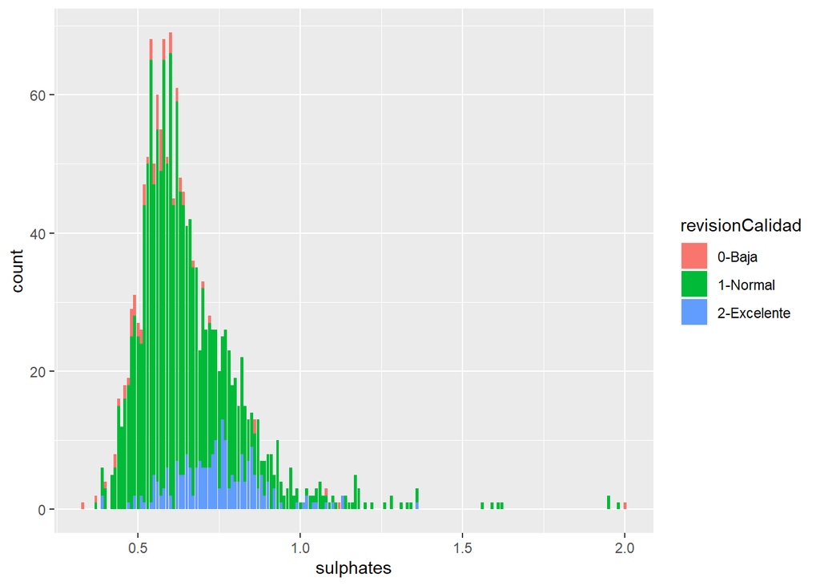

```r
ggplot(data = dataWine[1:filas,],aes(x=sulphates,fill=revisionCalidad))+geom_bar()
```

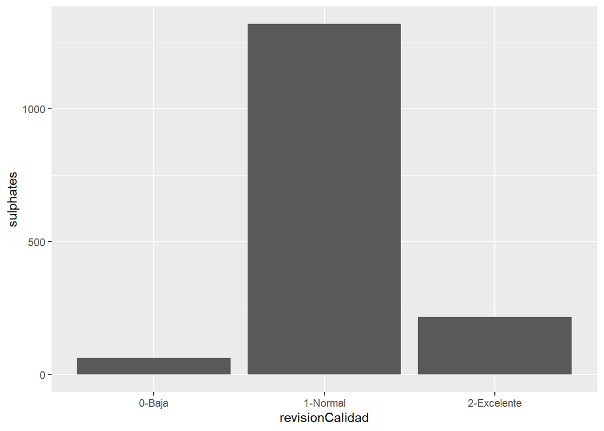

```r
ggplot(data = dataWine[1:filas,],aes(x=revisionCalidad,fill=sulphates))+geom_bar()+ylab("sulphates")
```

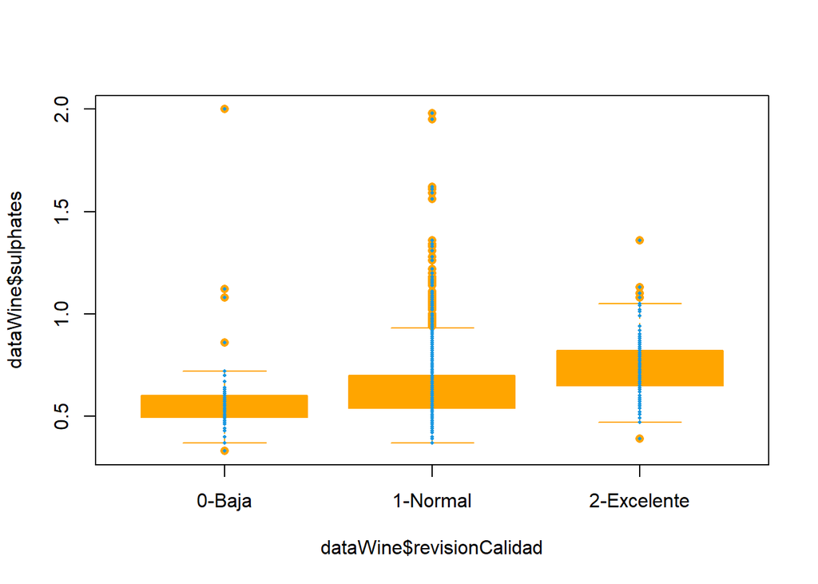

```r
boxplot(dataWine$sulphates ~ dataWine$revisionCalidad,
        col = "orange",
        border = "orange",
        pch = 16)

points(dataWine$revisionCalidad, dataWine$sulphates,
       col = "#1b98e0",
       pch = 16,
       cex = 0.4)
```

```r
#Atributo alcohol
print("Distribución de alcohol")
```

```
## [1] "Distribución de alcohol"
```

```r
summary(dataWine$alcohol)
```

```
##    Min. 1st Qu.  Median    Mean 3rd Qu.    Max.
##    8.40    9.50   10.20   10.42   11.10   14.90
```

```r
table(sort(dataWine$alcohol))
```

```
##
##              8.4              8.5              8.7              8.8
##                2                1                2                2
##                9             9.05              9.1              9.2
##               30                1               23               72
## 9.23333333333333             9.25              9.3              9.4
##                1                1               59              103
##              9.5             9.55 9.56666666666667              9.6
##              139                2                1               59
##              9.7              9.8              9.9             9.95
##               54               78               49                1
##               10 10.0333333333333             10.1             10.2
##               67                2               47               46
##             10.3             10.4             10.5            10.55
##               33               41               67                2
##             10.6             10.7            10.75             10.8
##               28               27                1               42
##             10.9               11 11.0666666666667             11.1
##               49               59                1               27
##             11.2             11.3             11.4             11.5
##               36               32               32               30
##             11.6             11.7             11.8             11.9
##               15               23               29               20
##            11.95               12             12.1             12.2
##                1               21               13               12
##             12.3             12.4             12.5             12.6
##               12               13               21                6
##             12.7             12.8             12.9               13
##                9               17                9                6
##             13.1             13.2             13.3             13.4
##                2                1                3                3
##             13.5 13.5666666666667             13.6               14
##                1                1                4                7
##             14.9
##                1
```

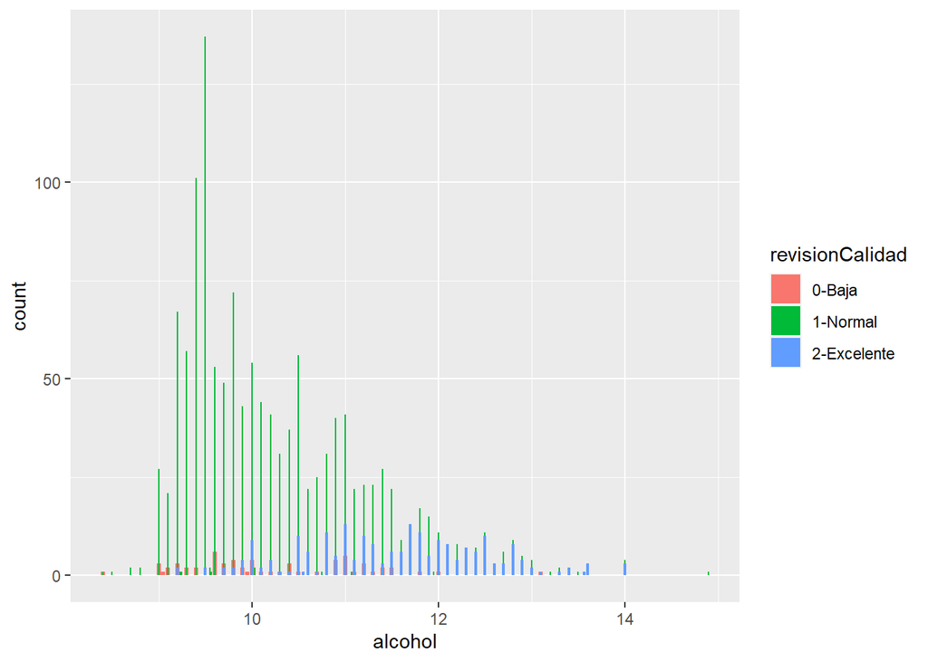

```r
ggplot(data = dataWine[1:filas,],aes(x=alcohol,fill=revisionCalidad))+geom_bar()
```

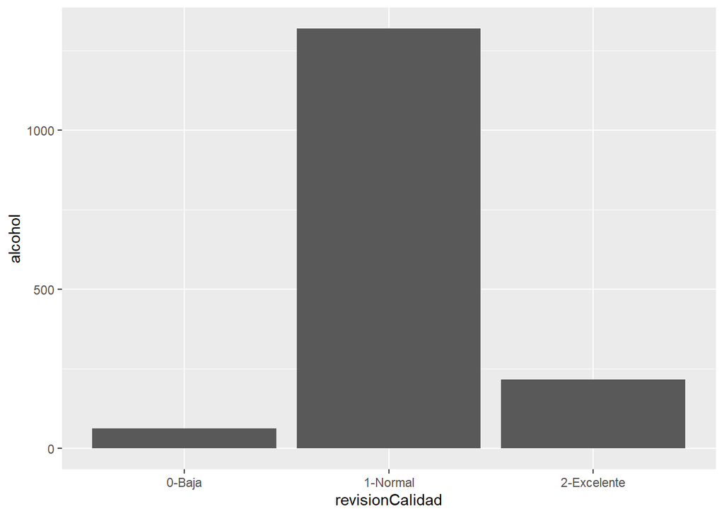

```r
ggplot(data = dataWine[1:filas,],aes(x=revisionCalidad,fill=alcohol))+geom_bar()+ylab("alcohol")
```

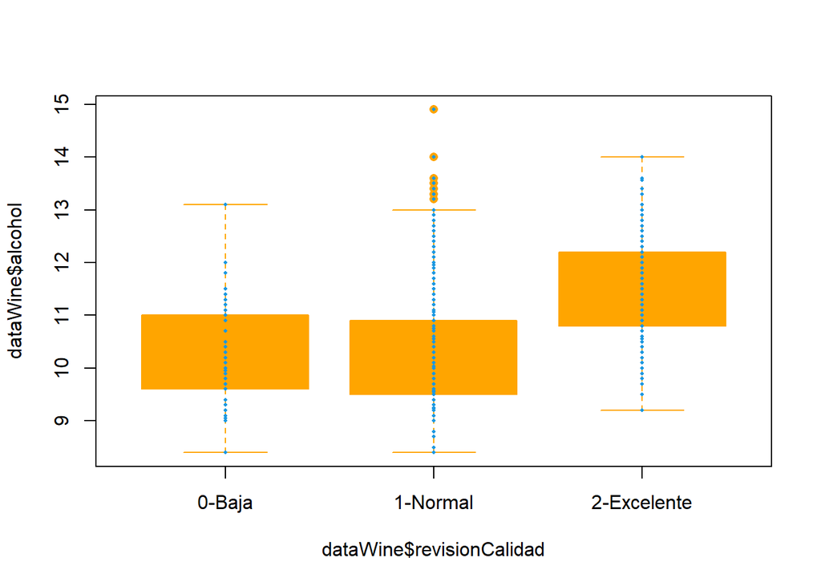

```r
boxplot(dataWine$alcohol ~ dataWine$revisionCalidad,
        col = "orange",
        border = "orange",
        pch = 16)

points(dataWine$revisionCalidad, dataWine$alcohol,
       col = "#1b98e0",
       pch = 16,
       cex = 0.4)
```

> Calculo de Outliers

Se considera outlier todo valor de un atributo que esté a más de 3 desviaciones estándar de la media.

```r
# Función que calcula Outliers a partir de un data frame.
zscore_outlier <- function(df) {
  output <- NULL
  media <- mean(df)
  desvStd <- sd(df)

  for (i in 1:length(df)) {
    if (abs((df[i]-media)/desvStd)>3) {
      output <- c(output,df[i])
    }
  }
  return(output)
}

# Se recorren las columnas relevantes para enumerar los outliers.
for (columna in colnames(dataWine[1:11])) {
  print(sprintf("Atributo: %s",columna))
  list_outlier <- zscore_outlier(dataWine[,columna])
  print(sort(list_outlier))
}
```

```
## [1] "Atributo: fixed.acidity"
##  [1] 13.7 13.7 13.8 14.0 14.3 15.0 15.0 15.5 15.5 15.6 15.6 15.9
## [1] "Atributo: volatile.acidity"
##  [1] 1.070 1.090 1.115 1.130 1.180 1.185 1.240 1.330 1.330 1.580
## [1] "Atributo: citric.acid"
## [1] 1
## [1] "Atributo: residual.sugar"
##  [1]  7.0  7.2  7.3  7.5  7.8  7.8  7.9  7.9  7.9  8.1  8.1  8.3  8.3  8.3  8.6
## [16]  8.8  8.8  8.9  9.0 10.7 11.0 11.0 12.9 13.4 13.8 13.8 13.9 15.4 15.4 15.5
## [1] "Atributo: chlorides"
##  [1] 0.230 0.235 0.236 0.241 0.243 0.250 0.263 0.267 0.270 0.332 0.337 0.341
## [13] 0.343 0.358 0.360 0.368 0.369 0.387 0.401 0.403 0.413 0.414 0.414 0.415
## [25] 0.415 0.415 0.422 0.464 0.467 0.610 0.611
## [1] "Atributo: free.sulfur.dioxide"
##  [1] 48 48 48 48 50 50 51 51 51 51 52 52 52 53 54 55 55 57 66 68 68 72
## [1] "Atributo: total.sulfur.dioxide"
##  [1] 147 147 147 148 148 149 151 151 152 153 155 160 165 278 289
## [1] "Atributo: density"
##  [1] 0.99007 0.99007 0.99020 0.99064 0.99064 0.99080 0.99084 1.00242 1.00242
## [10] 1.00260 1.00260 1.00289 1.00315 1.00315 1.00315 1.00320 1.00369 1.00369
## [1] "Atributo: pH"
## [1] 2.74 3.78 3.78 3.85 3.90 3.90 4.01 4.01
## [1] "Atributo: sulphates"
##  [1] 1.17 1.17 1.17 1.17 1.17 1.18 1.18 1.18 1.20 1.22 1.26 1.28 1.28 1.31 1.33
## [16] 1.34 1.36 1.36 1.36 1.56 1.59 1.61 1.62 1.95 1.95 1.98 2.00
## [1] "Atributo: alcohol"
## [1] 14.0 14.0 14.0 14.0 14.0 14.0 14.0 14.9
```

# 3 Limpieza de los datos

> Tratamiento Outliers.

Optamos por eliminar los Outliers obtenido previamente, asumiendo que son valores perdidos o tomados erróneamente en las mediciones, con el objeto de que no condicione la solución.

```r
dataWineAux <- dataWine
# Eliminamos Outliers.
# Nos basamos en los valores obtenidos y confirmados en apartado anterior.
dataWineAux$fixed.acidity[dataWineAux$fixed.acidity>=13.7] <- NA
dataWineAux$volatile.acidity[dataWineAux$volatile.acidity>=1.07] <- NA
dataWineAux$citric.acid[dataWineAux$citric.acid==1.0] <- NA
dataWineAux$residual.sugar[dataWineAux$residual.sugar>=7.0] <- NA
dataWineAux$chlorides[dataWineAux$chlorides>=0.23] <- NA
dataWineAux$free.sulfur.dioxide[dataWineAux$free.sulfur.dioxide>=48.0] <- NA
dataWineAux$total.sulfur.dioxide[dataWineAux$total.sulfur.dioxide>=147.0] <- NA
dataWineAux$density[dataWineAux$density<=0.99084] <- NA
dataWineAux$density[dataWineAux$density>=1.00242] <- NA
dataWineAux$pH[dataWineAux$pH<=2.74] <- NA
dataWineAux$pH[dataWineAux$pH>=3.78] <- NA
dataWineAux$sulphates[dataWineAux$sulphates>=1.17] <- NA
dataWineAux$alcohol[dataWineAux$alcohol>=14.0] <- NA

# Se omite los NA asignados previamente
dataWineFinal=na.omit(dataWineAux)
dataWineAux <- NULL
```

# 4 Análisis de los datos.

> Chequeo de la Normalidad y de la homogeneidad de la varianza (Homocedasticidad)

Se verifica la Normalidad de los atributos con shapiro.test (y con Kolmogorov-Smirnov en algunos casos). En ambos casos, el resultado es que no se puede concluir con estos tests de Normalidad que ninguno de los atributos siga una distribución Normal.

Si el p-valor es menor al nivel de significancia (0.05), entonces generalmente la hipótesis nula es rechazada y se concluye que los datos no cuentan con una distribución normal. Si, por el contrario, el p-valor es mayor a (0.05), se concluye que no se puede rechazar dicha hipótesis y se asume que los datos siguen una distribución normal.

En todos los casos, el p-valor es inferior a 0.05.

```r
library(car)
# Comprobación Normalidad
# Shapiro-Wilk
# Se construye la Matriz para el análisis a partir de los atributos seleccionados.
ks.test(dataWine$fixed.acidity, pnorm, mean(dataWine$fixed.acidity), sd(dataWine$fixed.acidity))
```

```
##
##  One-sample Kolmogorov-Smirnov test
##
## data:  dataWine$fixed.acidity
## D = 0.1105, p-value < 2.2e-16
## alternative hypothesis: two-sided
```

```r
shapiro.test(dataWine$fixed.acidity)
```

```
##
##  Shapiro-Wilk normality test
##
## data:  dataWine$fixed.acidity
## W = 0.94203, p-value < 2.2e-16
```

```r
# Se construye la Matriz para el análisis a partir de los atributos seleccionados.
#ks.test(dataWine$fixed.acidity, pnorm, mean(dataWine$fixed.acidity), sd(dataWine$fixed.acidity))
#shapiro.test(dataWine$fixed.acidity)

# Comprobación Homocedasticidad
# la hipótesis nula asume igualdad de varianzas en los diferentes grupos de datos, por lo que p-valores inferiores al nivel de significancia indicarán heterocedasticidad.
leveneTest(dataWine$fixed.acidity~dataWine$revisionCalidad,dataWine)
```

```
## Levene's Test for Homogeneity of Variance (center = median)
##         Df F value   Pr(>F)
## group    2  6.6339 0.001352 **
##       1596
## ---
## Signif. codes:  0 '***' 0.001 '**' 0.01 '*' 0.05 '.' 0.1 ' ' 1
```

```r
# Comprobación Homocedasticidad - SI NO se cumple Normalidad
fligner.test(dataWine$fixed.acidity~dataWine$revisionCalidad,dataWine)
```

```
##
##  Fligner-Killeen test of homogeneity of variances
##
## data:  dataWine$fixed.acidity by dataWine$revisionCalidad
## Fligner-Killeen:med chi-squared = 16.951, df = 2, p-value = 0.0002085
```

```r
# Otros Atributos
shapiro.test(dataWine$volatile.acidity)
```

```
##
##  Shapiro-Wilk normality test
##
## data:  dataWine$volatile.acidity
## W = 0.97434, p-value = 2.693e-16
```

```r
shapiro.test(dataWine$fixed.acidity)
```

```
##
##  Shapiro-Wilk normality test
##
## data:  dataWine$fixed.acidity
## W = 0.94203, p-value < 2.2e-16
```

```r
shapiro.test(dataWine$citric.acid)
```

```
##
##  Shapiro-Wilk normality test
##
## data:  dataWine$citric.acid
## W = 0.95529, p-value < 2.2e-16
```

```r
shapiro.test(dataWine$residual.sugar)
```

```
##
##  Shapiro-Wilk normality test
##
## data:  dataWine$residual.sugar
## W = 0.56608, p-value < 2.2e-16
```

```r
shapiro.test(dataWine$chlorides)
```

```
##
##  Shapiro-Wilk normality test
##
## data:  dataWine$chlorides
## W = 0.48425, p-value < 2.2e-16
```

```r
shapiro.test(dataWine$free.sulfur.dioxide)
```

```
##
##  Shapiro-Wilk normality test
##
## data:  dataWine$free.sulfur.dioxide
## W = 0.90184, p-value < 2.2e-16
```

```r
shapiro.test(dataWine$total.sulfur.dioxide)
```

```
##
##  Shapiro-Wilk normality test
##
## data:  dataWine$total.sulfur.dioxide
## W = 0.87322, p-value < 2.2e-16
```

```r
shapiro.test(dataWine$density)
```

```
##
##  Shapiro-Wilk normality test
##
## data:  dataWine$density
## W = 0.99087, p-value = 1.936e-08
```

```r
shapiro.test(dataWine$pH)
```

```
##
##  Shapiro-Wilk normality test
##
## data:  dataWine$pH
## W = 0.99349, p-value = 1.712e-06
```

```r
shapiro.test(dataWine$sulphates)
```

```
##
##  Shapiro-Wilk normality test
##
## data:  dataWine$sulphates
## W = 0.83304, p-value < 2.2e-16
```

```r
shapiro.test(dataWine$alcohol)
```

```
##
##  Shapiro-Wilk normality test
##
## data:  dataWine$alcohol
## W = 0.92884, p-value < 2.2e-16
```

Chequeo NORMALIDAD y Homocedasticidad - sobre dataSet sin Outliers

```r
library(car)
# Comprobación Normalidad
# Shapiro-Wilk
ks.test(dataWineFinal$fixed.acidity, pnorm, mean(dataWineFinal$fixed.acidity), sd(dataWineFinal$fixed.acidity))
```

```
##
##  One-sample Kolmogorov-Smirnov test
##
## data:  dataWineFinal$fixed.acidity
## D = 0.11141, p-value = 3.331e-16
## alternative hypothesis: two-sided
```

```r
shapiro.test(dataWineFinal$fixed.acidity)
```

```
##
##  Shapiro-Wilk normality test
##
## data:  dataWineFinal$fixed.acidity
## W = 0.94625, p-value < 2.2e-16
```

```r
#ks.test(dataWine$fixed.acidity, pnorm, mean(dataWine$fixed.acidity), sd(dataWine$fixed.acidity))
#shapiro.test(dataWine$fixed.acidity)

# Comprobación Homocedasticidad - SI se cumple Normalidad
# la hipótesis nula asume igualdad de varianzas en los diferentes grupos de datos, por lo que p-valores inferiores al nivel de significancia indicarán heterocedasticidad.
leveneTest(dataWineFinal$fixed.acidity~dataWineFinal$revisionCalidad,dataWineFinal)
```

```
## Levene's Test for Homogeneity of Variance (center = median)
##         Df F value  Pr(>F)
## group    2  4.0199 0.01816 *
##       1455
## ---
## Signif. codes:  0 '***' 0.001 '**' 0.01 '*' 0.05 '.' 0.1 ' ' 1
```

```r
# Comprobación Homocedasticidad - SI NO se cumple Normalidad
#fligner.test(dataWineFinal$fixed.acidity~dataWineFinal$revisionCalidad,dataWineFinal)


# Resto de Atributos
shapiro.test(dataWineFinal$volatile.acidity)
```

```
##
##  Shapiro-Wilk normality test
##
## data:  dataWineFinal$volatile.acidity
## W = 0.98556, p-value = 6.927e-11
```

```r
leveneTest(dataWineFinal$fixed.acidity~dataWineFinal$revisionCalidad,dataWineFinal)
```

```
## Levene's Test for Homogeneity of Variance (center = median)
##         Df F value  Pr(>F)
## group    2  4.0199 0.01816 *
##       1455
## ---
## Signif. codes:  0 '***' 0.001 '**' 0.01 '*' 0.05 '.' 0.1 ' ' 1
```

```r
shapiro.test(dataWineFinal$citric.acid)
```

```
##
##  Shapiro-Wilk normality test
##
## data:  dataWineFinal$citric.acid
## W = 0.95256, p-value < 2.2e-16
```

```r
leveneTest(dataWineFinal$citric.acid~dataWineFinal$revisionCalidad,dataWineFinal)
```

```
## Levene's Test for Homogeneity of Variance (center = median)
##         Df F value Pr(>F)
## group    2  0.4232  0.655
##       1455
```

```r
shapiro.test(dataWineFinal$residual.sugar)
```

```
##
##  Shapiro-Wilk normality test
##
## data:  dataWineFinal$residual.sugar
## W = 0.74977, p-value < 2.2e-16
```

```r
leveneTest(dataWineFinal$residual.sugar~dataWineFinal$revisionCalidad,dataWineFinal)
```

```
## Levene's Test for Homogeneity of Variance (center = median)
##         Df F value    Pr(>F)
## group    2  14.195 7.842e-07 ***
##       1455
## ---
## Signif. codes:  0 '***' 0.001 '**' 0.01 '*' 0.05 '.' 0.1 ' ' 1
```

```r
shapiro.test(dataWineFinal$chlorides)
```

```
##
##  Shapiro-Wilk normality test
##
## data:  dataWineFinal$chlorides
## W = 0.83672, p-value < 2.2e-16
```

```r
leveneTest(dataWineFinal$chlorides~dataWineFinal$revisionCalidad,dataWineFinal)
```

```
## Levene's Test for Homogeneity of Variance (center = median)
##         Df F value Pr(>F)
## group    2  1.1303 0.3232
##       1455
```

```r
shapiro.test(dataWineFinal$free.sulfur.dioxide)
```

```
##
##  Shapiro-Wilk normality test
##
## data:  dataWineFinal$free.sulfur.dioxide
## W = 0.92505, p-value < 2.2e-16
```

```r
leveneTest(dataWineFinal$free.sulfur.dioxide~dataWineFinal$revisionCalidad,dataWineFinal)
```

```
## Levene's Test for Homogeneity of Variance (center = median)
##         Df F value Pr(>F)
## group    2  1.6084 0.2006
##       1455
```

```r
shapiro.test(dataWineFinal$total.sulfur.dioxide)
```

```
##
##  Shapiro-Wilk normality test
##
## data:  dataWineFinal$total.sulfur.dioxide
## W = 0.89188, p-value < 2.2e-16
```

```r
leveneTest(dataWineFinal$total.sulfur.dioxide~dataWineFinal$revisionCalidad,dataWineFinal)
```

```
## Levene's Test for Homogeneity of Variance (center = median)
##         Df F value    Pr(>F)
## group    2  14.282 7.201e-07 ***
##       1455
## ---
## Signif. codes:  0 '***' 0.001 '**' 0.01 '*' 0.05 '.' 0.1 ' ' 1
```

```r
shapiro.test(dataWineFinal$density)
```

```
##
##  Shapiro-Wilk normality test
##
## data:  dataWineFinal$density
## W = 0.99712, p-value = 0.009119
```

```r
leveneTest(dataWineFinal$density~dataWineFinal$revisionCalidad,dataWineFinal)
```

```
## Levene's Test for Homogeneity of Variance (center = median)
##         Df F value   Pr(>F)
## group    2  6.6968 0.001273 **
##       1455
## ---
## Signif. codes:  0 '***' 0.001 '**' 0.01 '*' 0.05 '.' 0.1 ' ' 1
```

```r
shapiro.test(dataWineFinal$pH)
```

```
##
##  Shapiro-Wilk normality test
##
## data:  dataWineFinal$pH
## W = 0.99726, p-value = 0.0125
```

```r
leveneTest(dataWineFinal$pH~dataWineFinal$revisionCalidad,dataWineFinal)
```

```
## Levene's Test for Homogeneity of Variance (center = median)
##         Df F value Pr(>F)
## group    2  0.0939 0.9103
##       1455
```

```r
shapiro.test(dataWineFinal$sulphates)
```

```
##
##  Shapiro-Wilk normality test
##
## data:  dataWineFinal$sulphates
## W = 0.95127, p-value < 2.2e-16
```

```r
leveneTest(dataWineFinal$sulphates~dataWineFinal$revisionCalidad,dataWineFinal)
```

```
## Levene's Test for Homogeneity of Variance (center = median)
##         Df F value Pr(>F)
## group    2  0.3296 0.7193
##       1455
```

```r
shapiro.test(dataWineFinal$alcohol)
```

```
##
##  Shapiro-Wilk normality test
##
## data:  dataWineFinal$alcohol
## W = 0.93383, p-value < 2.2e-16
```

```r
leveneTest(dataWineFinal$alcohol~dataWineFinal$revisionCalidad,dataWineFinal)
```

```
## Levene's Test for Homogeneity of Variance (center = median)
##         Df F value Pr(>F)
## group    2  0.6898 0.5018
##       1455
```

> Correlación de los atributos.

Examinamos la matriz de correlación de las variables númericas del conjunto de datos.

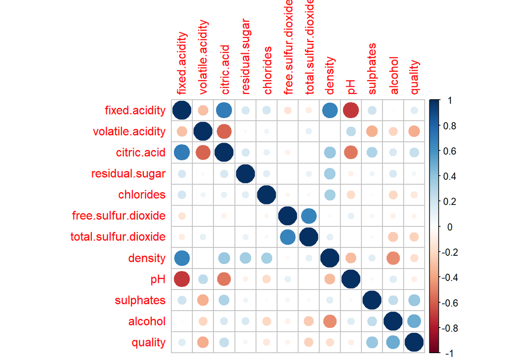

```r
library(corrplot)
corr.res<-cor(dataWineFinal[1:12])
corrplot(corr.res,method="circle")
```

Se observa una correlación relevante entre las siguientes variables: * fixed.acidity y citric.acid * fixed.acidity y density * fixed.acidity y pH * volatile.acidity y citric.acid * density y citric.acid * citric.acid y pH * free.sulfur.dioxide y total.sulfur.dioxide

Sin embargo, no existe una correlación tan significativa que aconseje una reducción de la dimensionalidad eliminando algún atributo dependiente de otro. Esto implicaría seguramente pérdida de información. Por tanto, continua el análisis manteniendo el mismo número de atributos.

> Preparación de los conjuntos de datos de entrenamiento y prueba.

```r
set.seed(1)
dataWineFinal_random <- dataWineFinal[sample(nrow(dataWineFinal)),]
dataWineFinal_randomLineal <- dataWineFinal_random[1:12]

# La clase objetivo a predecir es revisionCalidad
y <- dataWineFinal_random[,13]
X <- dataWineFinal_random[,1:11]

# Formamos el conjunto de datos de entrenamiento y test a partir de los 2/3 y 1/3 del conjunto de datos inicial, ordenado de forma aleatoria.
trainX <- X[1:972,]
trainy <- y[1:972]
testX <- X[972:1458,]
testy <- y[972:1458]
```

> Análisis KNN

En primer lugar,como paso previo, intentaremos tener alguna aproximación del número de cluster óptimo. Utilizamos el paquete NbClust para conseguir información del número de cluster óptimo entre 2 y 10.

```r
#Cargamos paquetes requeridos
library(factoextra)
library(NbClust)

nbclust_out <- NbClust(
  data = trainX,
  distance = "euclidean",
  min.nc = 2,
  max.nc = 10,
  method = "ward.D" #kmeans
)
```

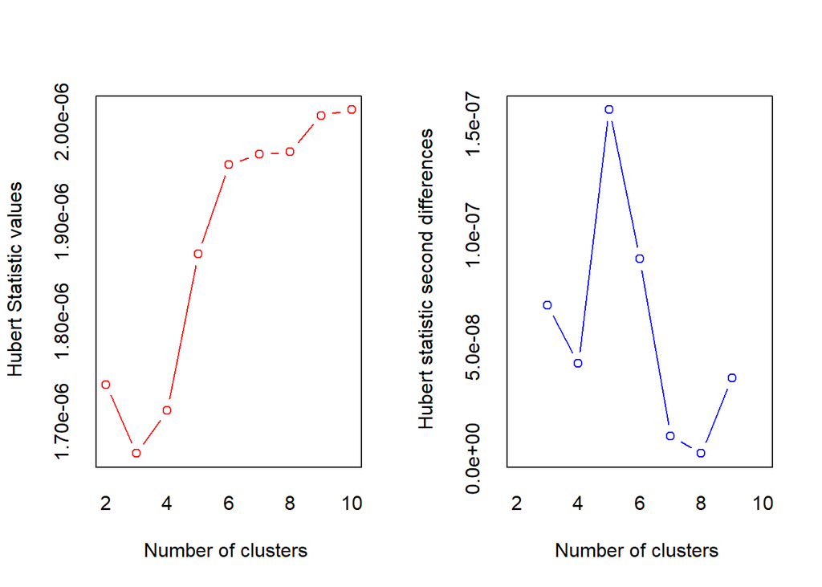

```
## *** : The Hubert index is a graphical method of determining the number of clusters.
##                 In the plot of Hubert index, we seek a significant knee that corresponds to a
##                 significant increase of the value of the measure i.e the significant peak in Hubert
##                 index second differences plot.
##
```

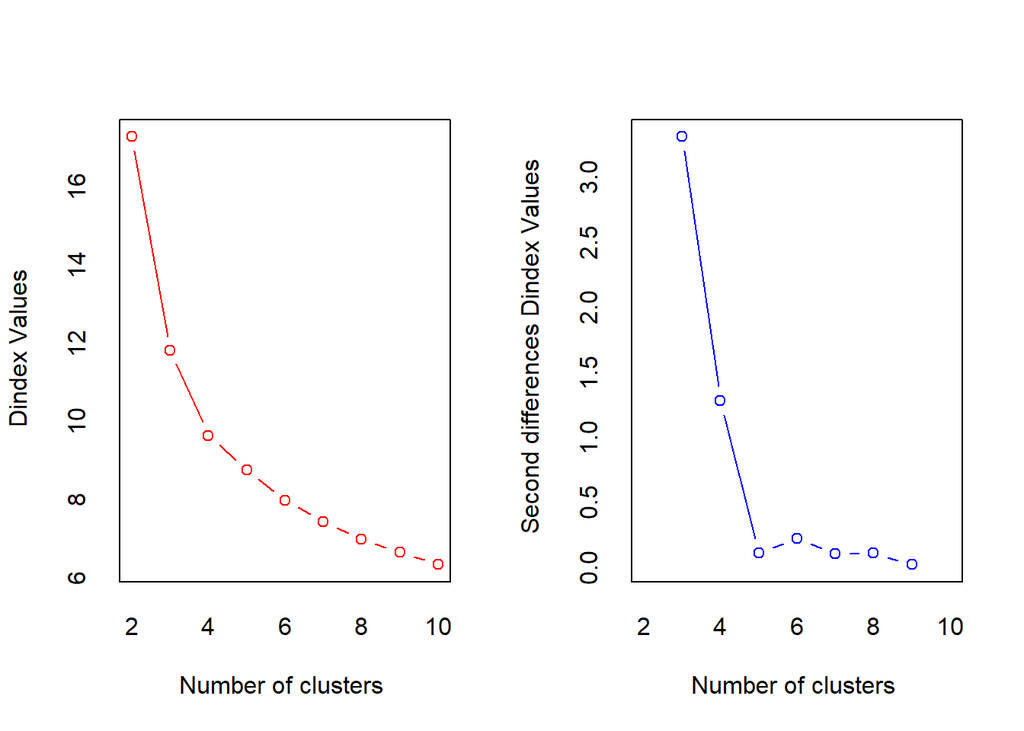

```
## *** : The D index is a graphical method of determining the number of clusters.
##                 In the plot of D index, we seek a significant knee (the significant peak in Dindex
##                 second differences plot) that corresponds to a significant increase of the value of
##                 the measure.
##
## * Among all indices:
## * 7 proposed 2 as the best number of clusters
## * 7 proposed 3 as the best number of clusters
## * 1 proposed 4 as the best number of clusters
## * 5 proposed 5 as the best number of clusters
## * 1 proposed 10 as the best number of clusters
##
##                    ***** Conclusion *****
##
## * According to the majority rule, the best number of clusters is  2
##
##
```

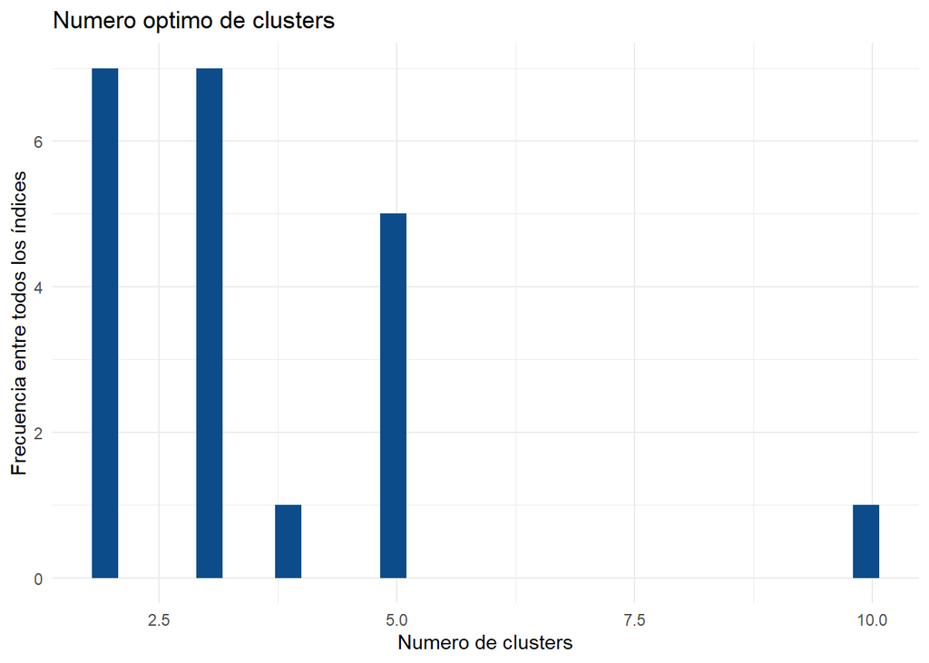

```r
# Se crea un dataframe del numero optimo de clusters
nbclust_plot <- data.frame(clusters = nbclust_out$Best.nc[1, ])
# select only indices which select between 2 and 10 clusters
nbclust_plot <- subset(nbclust_plot, clusters >= 2 & clusters <= 10)

# create plot
ggplot(nbclust_plot) +
  aes(x = clusters) +
  geom_histogram(bins = 30L, fill = "#0c4c8a") +
  labs(x = "Numero de clusters", y = "Frecuencia entre todos los índices", title = "Numero optimo de clusters") +
  theme_minimal()
```

El resultado indica que el número óptimo de cluster es 2. No parece concluyente. Examinando los diagramas de Hubert, observamos que el codo podría locaizarse entre 4 cluster (aunque podría ser un mínimo local) y 7 clusters.

Para el algoritmo KNN, emplearemos el paquete Caret.

```r
library(caret)

# Se empleará Cross Validation
ctrl <- trainControl(method="repeatedcv",repeats = 3)
knnFit <- train(trainX,trainy, method = "knn", trControl = ctrl, preProcess = c("center","scale"), tuneLength = 20)

knnFit
```

```
## k-Nearest Neighbors
##
## 972 samples
##  11 predictor
##   3 classes: '0-Baja', '1-Normal', '2-Excelente'
##
## Pre-processing: centered (11), scaled (11)
## Resampling: Cross-Validated (10 fold, repeated 3 times)
## Summary of sample sizes: 875, 874, 874, 875, 875, 875, ...
## Resampling results across tuning parameters:
##
##   k   Accuracy   Kappa
##    5  0.8330439  0.3407574
##    7  0.8364670  0.3374844
##    9  0.8388551  0.3390454
##   11  0.8371542  0.3226681
##   13  0.8372278  0.3070074
##   15  0.8392968  0.2937392
##   17  0.8399597  0.2930574
##   19  0.8361966  0.2754027
##   21  0.8358319  0.2592719
##   23  0.8361967  0.2537311
##   25  0.8330966  0.2308206
##   27  0.8334469  0.2302331
##   29  0.8334506  0.2254532
##   31  0.8313747  0.2145026
##   33  0.8347762  0.2229030
##   35  0.8358214  0.2277380
##   37  0.8375220  0.2215352
##   39  0.8361437  0.2141604
##   41  0.8385461  0.2222324
##   43  0.8375256  0.2105929
##
## Accuracy was used to select the optimal model using the largest value.
## The final value used for the model was k = 17.
```

```r
predicted_model <- predict( knnFit, testX, type="raw" )
print(sprintf("La precisión de KNN es: %.2f %%",100*sum(predicted_model == testy) / length(predicted_model)))
```

```
## [1] "La precisión de KNN es: 85.42 %"
```

> Análisis Arbol Decision

Para el árbol de decisión, obtendremos también las reglas de decisión. Para ello, utilizaremos el paquete C50.

```r
trainy = as.factor(trainy)
model_rules <- C50::C5.0(trainX, trainy,rules=TRUE )
summary(model_rules)
```

```
##
## Call:
## C5.0.default(x = trainX, y = trainy, rules = TRUE)
##
##
## C5.0 [Release 2.07 GPL Edition]      Mon Jan 04 22:08:16 2021
## -------------------------------
##
## Class specified by attribute `outcome'
##
## Read 972 cases (12 attributes) from undefined.data
##
## Rules:
##
## Rule 1: (4, lift 21.9)
##  volatile.acidity > 0.365
##  chlorides <= 0.111
##  free.sulfur.dioxide <= 4
##  density <= 0.99694
##  sulphates > 0.53
##  alcohol > 10.4
##  alcohol <= 12
##  ->  class 0-Baja  [0.833]
##
## Rule 2: (4, lift 21.9)
##  volatile.acidity > 0.9
##  density > 0.99584
##  alcohol > 10.4
##  ->  class 0-Baja  [0.833]
##
## Rule 3: (4, lift 21.9)
##  volatile.acidity > 1.01
##  alcohol > 10.4
##  ->  class 0-Baja  [0.833]
##
## Rule 4: (11/5, lift 14.1)
##  volatile.acidity > 0.9
##  sulphates <= 0.68
##  alcohol > 10.4
##  ->  class 0-Baja  [0.538]
```

[output cut: 190 more lines]

```
##
##   94.55% alcohol
##   81.48% volatile.acidity
##   80.56% sulphates
##   75.10% free.sulfur.dioxide
##   72.53% residual.sugar
##   71.60% citric.acid
##   56.48% total.sulfur.dioxide
##   55.76% pH
##   24.18% density
##   13.99% chlorides
##    0.72% fixed.acidity
##
##
## Time: 0.0 secs
```

El árbol de decisión genera 20 reglas de decisión, con lo que consiguen clasificar correctamente el conjunto de entrenamiento salvo en 74 casos (7% de los casos).

```r
predicted_model <- predict( model_rules, testX, type="class" )
print(sprintf("La precisión del árbol es: %.2f %%",100*sum(predicted_model == testy) / length(predicted_model)))
```

```
## [1] "La precisión del árbol es: 86.65 %"
```

> Tunning: Iteración (Boosting adaptativo) del árbol del decisión.

A continuación, utilizaremos el Boosting adaptativo para intentar mejorar el modelo del árbol de decisión.

Adicionalmente, cargaremos el paquete gmodels, para utilizar Crosstable y obtener más información en la matriz de confusión, concretamente los porcentajes en cada casilla, así como los totales por fila y columna.

```r
library(gmodels)

# Generamos modelo Boosted con 10 trial (lo habitual es indicar 10)
model_tree_boosted <- C50::C5.0(trainX, trainy,trial=10)
summary(model_tree_boosted)
```

```
##
## Call:
## C5.0.default(x = trainX, y = trainy, trials = 10)
##
##
## C5.0 [Release 2.07 GPL Edition]      Mon Jan 04 22:08:16 2021
## -------------------------------
##
## Class specified by attribute `outcome'
##
## Read 972 cases (12 attributes) from undefined.data
##
## -----  Trial 0:  -----
##
## Decision tree:
##
## alcohol <= 10.4:
## :...sulphates <= 0.64:
## :   :...total.sulfur.dioxide > 14: 1-Normal (348/16)
## :   :   total.sulfur.dioxide <= 14:
## :   :   :...pH <= 3.28: 1-Normal (13)
## :   :       pH > 3.28:
## :   :       :...pH > 3.52: 0-Baja (2)
## :   :           pH <= 3.52:
## :   :           :...pH > 3.37: 1-Normal (8)
## :   :               pH <= 3.37:
## :   :               :...total.sulfur.dioxide <= 9: 0-Baja (3)
## :   :                   total.sulfur.dioxide > 9:
## :   :                   :...fixed.acidity <= 9: 1-Normal (9/1)
## :   :                       fixed.acidity > 9: 0-Baja (2)
## :   sulphates > 0.64:
## :   :...residual.sugar <= 1.65:
## :       :...citric.acid > 0.46: 2-Excelente (2)
## :       :   citric.acid <= 0.46:
## :       :   :...sulphates <= 0.85: 1-Normal (11)
## :       :       sulphates > 0.85:
## :       :       :...volatile.acidity <= 0.45: 1-Normal (2)
## :       :           volatile.acidity > 0.45: 0-Baja (3)
## :       residual.sugar > 1.65:
## :       :...alcohol <= 9.95: 1-Normal (105/2)
```

[output cut: 1125 more lines]

```
##
##  100.00% volatile.acidity
##  100.00% sulphates
##  100.00% alcohol
##   99.90% residual.sugar
##   99.38% citric.acid
##   93.00% free.sulfur.dioxide
##   91.56% total.sulfur.dioxide
##   91.05% density
##   83.54% chlorides
##   83.44% pH
##   72.33% fixed.acidity
##
##
## Time: 0.1 secs
```

```r
predicted_model_boosted <- predict( model_tree_boosted, testX, type="class" )

# Crosstable para tener más info de la matriz de confusión
CrossTable(testy, predicted_model_boosted,prop.chisq  = FALSE, prop.c = FALSE, prop.r =FALSE,dnn = c('Reality', 'Prediction'))
```

```
##
##
##    Cell Contents
## |-------------------------|
## |                       N |
## |         N / Table Total |
## |-------------------------|
##
##
## Total Observations in Table:  487
##
##
##              | Prediction
##      Reality |      0-Baja |    1-Normal | 2-Excelente |   Row Total |
## -------------|-------------|-------------|-------------|-------------|
##       0-Baja |           1 |          16 |           0 |          17 |
##              |       0.002 |       0.033 |       0.000 |             |
## -------------|-------------|-------------|-------------|-------------|
##     1-Normal |           1 |         388 |          13 |         402 |
##              |       0.002 |       0.797 |       0.027 |             |
## -------------|-------------|-------------|-------------|-------------|
##  2-Excelente |           0 |          31 |          37 |          68 |
##              |       0.000 |       0.064 |       0.076 |             |
## -------------|-------------|-------------|-------------|-------------|
## Column Total |           2 |         435 |          50 |         487 |
## -------------|-------------|-------------|-------------|-------------|
##
##
```

```r
#Matriz de confusión para calcular la precisión del algoritmo con conjunto de test.
mat_conf<-table(testy,Predicted=predicted_model_boosted)

porcentaje_correct<-100 * sum(diag(mat_conf)) / sum(mat_conf)
print(sprintf("El %% de registros correctamente clasificados es: %.4f %%",porcentaje_correct))
```

```
## [1] "El % de registros correctamente clasificados es: 87.4743 %"
```

La variante que se ha aplicado es Boosting adaptativo, que se basa en aplicar diferentes iteraciones de clasificación sobre el mismo conjunto de datos de entrenamiento. El primer clasificador, tal y como hicimos con las reglas de decisión, cometió una serie de errores sobre los que trabajará el siguiente clasificador en la siguiente iteración, y así sucesivamente hasta que ya no haya mejora significativa o se llegue al número de iteraciones o trial indicado. Cada clasificador tiene su aportación a la hora de determinar la clase que se debe predecir. La gran diferencia, por tanto, es que no es un clasificador sino un conjunto de ellos.

En este ejemplo concreto, con 10 iteraciones se consigue clasificar correctamente todos los casos de entrenamiento. El % de muestras correctamente clasificadas en el el conjunto de datos de test es del 87%, mejorando lo que se tenía previamente.

EL uso de los atributos se incrementa al 100% en los siguientes atributos:

- Alcohol, volatile.acidity.

Adicionalmente, se incrementa en resto de variables. Todos los atributos forman parte, en mayor o menor medida, de la decisión de clasificación.

> RANDOM FOREST

Por último, aplicaremos el Random Forest que es un algoritmo basado en árboles, que es bastante conocido y potente.

```r
library(caret)

# Se empleará Cross Validation
ctrl <- trainControl(method="cv",repeats = 3)
rfFit <- train(trainX,trainy, method = "rf", trControl = ctrl, preProcess = c("center","scale"), tuneLength = 20)
rfFit
```

```
## Random Forest
##
## 972 samples
##  11 predictor
##   3 classes: '0-Baja', '1-Normal', '2-Excelente'
##
## Pre-processing: centered (11), scaled (11)
## Resampling: Cross-Validated (10 fold)
## Summary of sample sizes: 875, 874, 875, 874, 875, 874, ...
## Resampling results across tuning parameters:
##
##   mtry  Accuracy   Kappa
##    2    0.8704588  0.4336767
##    3    0.8673868  0.4392480
##    4    0.8704691  0.4586604
##    5    0.8642833  0.4388390
##    6    0.8601806  0.4216908
##    7    0.8632629  0.4480780
##    8    0.8642728  0.4510819
##    9    0.8663346  0.4673163
##   10    0.8601701  0.4433055
##   11    0.8591497  0.4439614
##
## Accuracy was used to select the optimal model using the largest value.
## The final value used for the model was mtry = 4.
```

```r
predicted_rf <- predict( rfFit, testX, type="raw" )

# Matriz de Confusión
confusionMatrix(predicted_rf,testy)
```

```
## Confusion Matrix and Statistics
##
##              Reference
## Prediction    0-Baja 1-Normal 2-Excelente
##   0-Baja           0        1           0
##   1-Normal        17      390          30
##   2-Excelente      0       11          38
##
## Overall Statistics
##
##                Accuracy : 0.8789
##                  95% CI : (0.8465, 0.9065)
##     No Information Rate : 0.8255
##     P-Value [Acc > NIR] : 0.0007617
##
##                   Kappa : 0.5058
##
##  Mcnemar's Test P-Value : NA
##
## Statistics by Class:
##
##                      Class: 0-Baja Class: 1-Normal Class: 2-Excelente
## Sensitivity               0.000000          0.9701            0.55882
## Specificity               0.997872          0.4471            0.97375
## Pos Pred Value            0.000000          0.8924            0.77551
## Neg Pred Value            0.965021          0.7600            0.93151
## Prevalence                0.034908          0.8255            0.13963
## Detection Rate            0.000000          0.8008            0.07803
## Detection Prevalence      0.002053          0.8973            0.10062
## Balanced Accuracy         0.498936          0.7086            0.76629
```

```r
#Precisión del algoritmo
print(sprintf("La precisión de RANDOM FOREST es: %.2f %%",100*sum(predicted_rf == testy) / length(predicted_rf)))
```

```
## [1] "La precisión de RANDOM FOREST es: 87.89 %"
```

Random Forest utiliza 4 candidatos para alimentar el algoritmo en nuestro caso particular.

Se obtiene una precisión ligeramente superior al conseguido con el Boosting Adaptativo previamente.